# Bayesian variable selection for red wine quality ranking data

Aki Vehtari

First version 2018-02-27. Last modified 2019-12-04.

# Setup

**Load packages**

```r
library(rstan)
library(rstanarm)
library(loo)
library(bayesplot)
theme_set(bayesplot::theme_default())
library(projpred)
SEED=170701694
```

# 1 Introduction

This notebook was inspired by Eric Novik’s slides “Deconstructing Stan Manual Part 1: Linear”. The idea is to demonstrate how easy it is to do good variable selection with [`rstanarm`](https://cran.r-project.org/package=rstanarm), [`loo`](https://cran.r-project.org/package=loo), and [`projpred`](https://cran.r-project.org/package=projpred).

In this notebook we illustrate Bayesian inference for model selection, including PSIS-LOO (Vehtari, Gelman and Gabry, 2017) and projection predictive approach (Piironen and Vehtari, 2017a; Piironen, Paasiniemi and Vehtari, 2018) which makes decision theoretically justified inference after model selection..

# 2 Wine quality data

We use [Wine quality data set from UCI Machine Learning repository](https://archive.ics.uci.edu/ml/datasets/wine+qualitycandy)

```r
d <- read.delim("winequality-red.csv", sep = ";")
dim(d)
```

```
[1] 1599   12
```

Remove duplicated

```r
d <- d[!duplicated(d), ] # remove the duplicates
dim(d)
```

```
[1] 1359   12
```

```r
names(d)
```

```
 [1] "fixed.acidity"        "volatile.acidity"     "citric.acid"
 [4] "residual.sugar"       "chlorides"            "free.sulfur.dioxide"
 [7] "total.sulfur.dioxide" "density"              "pH"
[10] "sulphates"            "alcohol"              "quality"
```

We scale the covariates so that when looking at the marginal posteriors for the effects they are on the same scale.

```r
ds <- scale(d)
df <- as.data.frame(ds)
```

# 3 Fit regression model

The `rstanarm` package provides `stan_glm` which accepts same arguments as `glm`, but makes full Bayesian inference using Stan (mc-stan.org). By default a weakly informative Gaussian prior is used for weights.

```r
fitg <- stan_glm(quality ~ ., data = df, QR=TRUE, seed=SEED, refresh=0)
```

Let’s look at the summary:

```r
monitor(fitg$stanfit)
```

```
Inference for the input samples (4 chains: each with iter = 2000; warmup = 0):

                          Q5     Q50     Q95    Mean  SD  Rhat Bulk_ESS
(Intercept)              0.0     0.0     0.0     0.0 0.0     1     4426
fixed.acidity           -0.1     0.0     0.1     0.0 0.1     1     5223
volatile.acidity        -0.3    -0.2    -0.2    -0.2 0.0     1     5530
citric.acid             -0.1     0.0     0.0     0.0 0.0     1     5580
residual.sugar           0.0     0.0     0.1     0.0 0.0     1     5303
chlorides               -0.2    -0.1    -0.1    -0.1 0.0     1     5315
free.sulfur.dioxide      0.0     0.0     0.1     0.0 0.0     1     4914
total.sulfur.dioxide    -0.2    -0.1    -0.1    -0.1 0.0     1     4958
density                 -0.1     0.0     0.1     0.0 0.1     1     5173
pH                      -0.2    -0.1     0.0    -0.1 0.0     1     5328
sulphates                0.1     0.2     0.2     0.2 0.0     1     4968
alcohol                  0.3     0.4     0.4     0.4 0.0     1     5063
sigma                    0.8     0.8     0.8     0.8 0.0     1     4708
mean_PPD                -0.1     0.0     0.1     0.0 0.0     1     4136
log-posterior        -1646.2 -1641.1 -1637.8 -1641.4 2.5     1     2129
                     Tail_ESS
(Intercept)              2823
fixed.acidity            2812
volatile.acidity         3214
citric.acid              3014
residual.sugar           3357
chlorides                2998
free.sulfur.dioxide      3092
total.sulfur.dioxide     2376
density                  3206
pH                       2947
sulphates                3180
alcohol                  2948
sigma                    3005
mean_PPD                 3698
log-posterior            2678

For each parameter, Bulk_ESS and Tail_ESS are crude measures of
effective sample size for bulk and tail quantities respectively (an ESS > 100
per chain is considered good), and Rhat is the potential scale reduction
factor on rank normalized split chains (at convergence, Rhat <= 1.05).
```

We didn’t get divergences, Rhat’s are less than 1.1 and n_eff’s are useful (see, e.g., [RStan workflow](http://mc-stan.org/users/documentation/case-studies/rstan_workflow.html)).

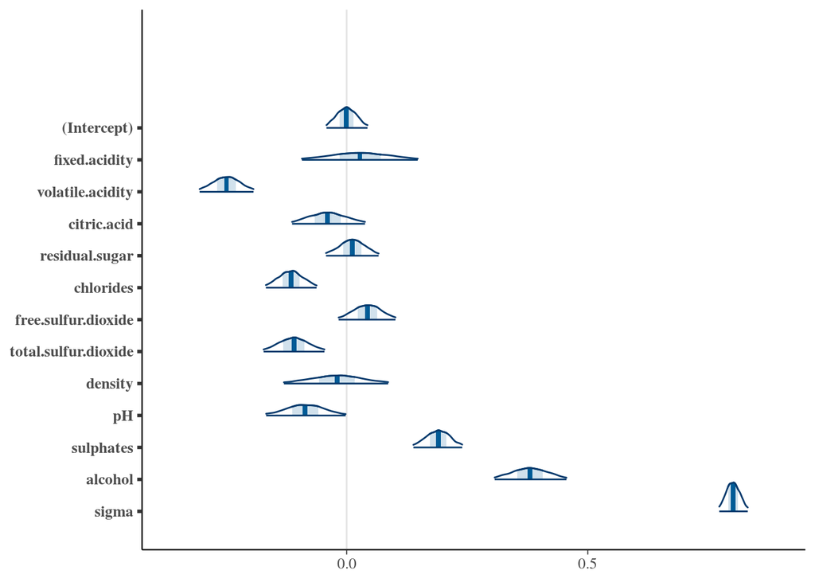

```r
mcmc_areas(as.matrix(fitg),prob_outer = .95)
```

Several 95% posterior intervals are not overlapping 0, so maybe there is something useful here.

# 4 Cross-validation checking

In case of collinear variables it is possible that marginal posteriors overlap 0, but the covariates can still useful for prediction. With many variables it will be difficult to analyse joint posterior to see which variables are jointly relevant. We can easily test whether any of the covariates are useful by using cross-validation to compare to a null model,

```r
fitg0 <- stan_glm(quality ~ 1, data = df, seed=SEED, refresh=0)
```

We use fast Pareto smoothed importance sampling leave-one-out cross-validation (Vehtari, Gelman and Gabry, 2017)

```r
(loog <- loo(fitg))
```

```
Computed from 4000 by 1359 log-likelihood matrix

         Estimate   SE
elpd_loo  -1635.4 30.6
p_loo        16.3  1.6
looic      3270.9 61.2
------
Monte Carlo SE of elpd_loo is 0.1.

Pareto k diagnostic values:
                         Count Pct.    Min. n_eff
(-Inf, 0.5]   (good)     1358  99.9%   1537
 (0.5, 0.7]   (ok)          1   0.1%   1485
   (0.7, 1]   (bad)         0   0.0%   <NA>
   (1, Inf)   (very bad)    0   0.0%   <NA>

All Pareto k estimates are ok (k < 0.7).
See help('pareto-k-diagnostic') for details.
```

```r
(loog0 <- loo(fitg0))
```

```
Computed from 4000 by 1359 log-likelihood matrix

         Estimate   SE
elpd_loo  -1929.9 28.2
p_loo         2.1  0.2
looic      3859.7 56.5
------
Monte Carlo SE of elpd_loo is 0.0.

All Pareto k estimates are good (k < 0.5).
See help('pareto-k-diagnostic') for details.
```

```r
loo_compare(loog0, loog)
```

```
      elpd_diff se_diff
fitg     0.0       0.0
fitg0 -294.4      22.9
```

Based on cross-validation covariates together have a high predictive power. If we need just the predictions we can stop here, but if we want to learn more about the relevance of the covariates we can continue with variable selection.

# 5 Projection predictive variable selection

We make the projective predictive variable selection (Piironen and Vehtari, 2017a; Piironen, Paasiniemi and Vehtari, 2018) using `projpred` package. A fast PSIS-LOO (Vehtari, Gelman and Gabry, 2017) is used to choose the model size.

```r
fitg_cv <- cv_varsel(fitg, method='forward', cv_method='LOO', n_loo=nrow(df))
```

```r
fitg_cv$vind
```

```
             alcohol     volatile.acidity            sulphates
                  11                    2                   10
           chlorides total.sulfur.dioxide                   pH
                   5                    7                    9
 free.sulfur.dioxide          citric.acid       residual.sugar
                   6                    3                    4
       fixed.acidity              density
                   1                    8
```

We can now look at the estimated predictive performance of smaller models compared to the full model.

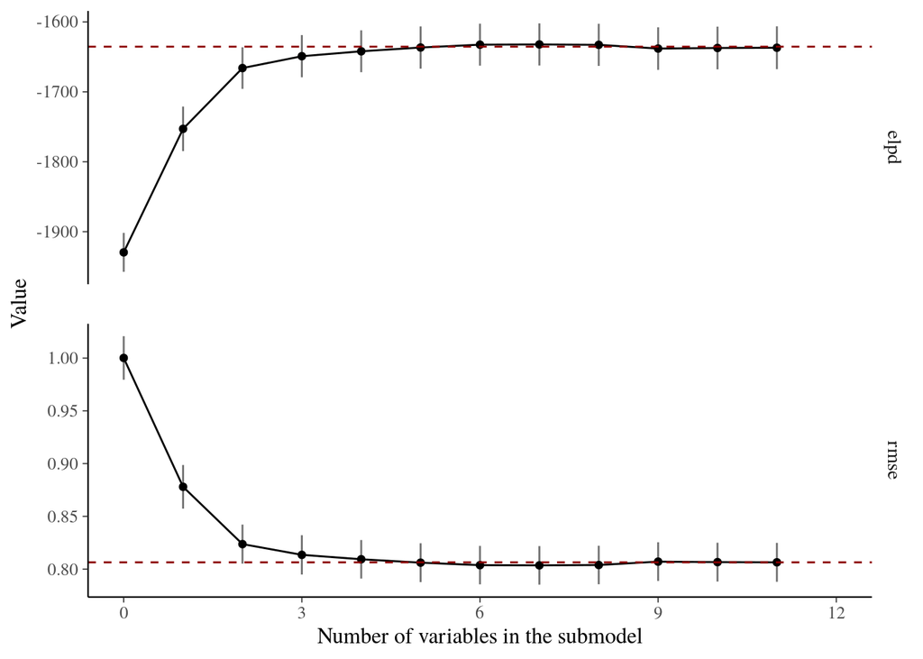

```r
varsel_plot(fitg_cv, stats = c('elpd', 'rmse'))
```

Three or four variables seems to be needed to get the same performance as the full model. We can get a loo-cv based recommendation for the model size to choose.

```r
(nv <- suggest_size(fitg_cv, alpha=0.1))
```

```
[1] 4
```

projpred recommends to use four variables: alcohol, volatile.acidity, sulphates, and chlorides.

Next we form the projected posterior for the chosen model. This projected model can be used in the future to make predictions by using only the selected variables.

```r
projg <- project(fitg_cv, nv = nv, ns = 4000)
round(colMeans(as.matrix(projg)), 1)
```

```
     (Intercept)          alcohol volatile.acidity        sulphates
             0.0              0.4             -0.3              0.2
       chlorides            sigma
            -0.1              0.8
```

```r
round(posterior_interval(as.matrix(projg)), 1)
```

```
                   5%  95%
(Intercept)       0.0  0.0
alcohol           0.4  0.4
volatile.acidity -0.3 -0.2
sulphates         0.1  0.2
chlorides        -0.1 -0.1
sigma             0.8  0.8
```

The marginals of projected posteriors look like this.

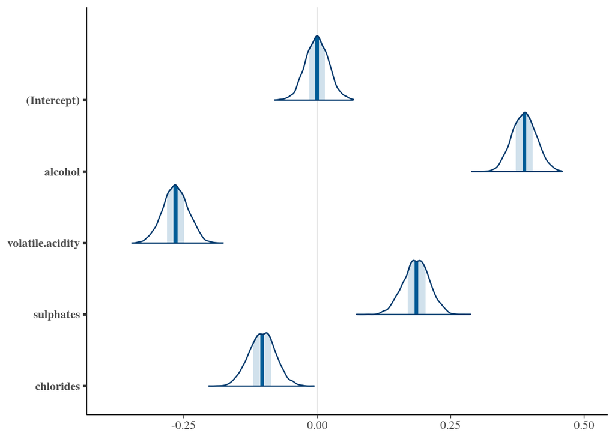

```r
mcmc_areas(as.matrix(projg),
           pars = c('(Intercept)', names(fitg_cv$vind[1:nv])))
```

# 6 Alternative regularized horseshoe prior

We also test regularized horseshoe prior (Piironen and Vehtari, 2017b) which has more prior mass near 0.

```r
fitrhs <- stan_glm(quality ~ ., data = df, prior=hs(),
                   seed=SEED, refresh=0)
```

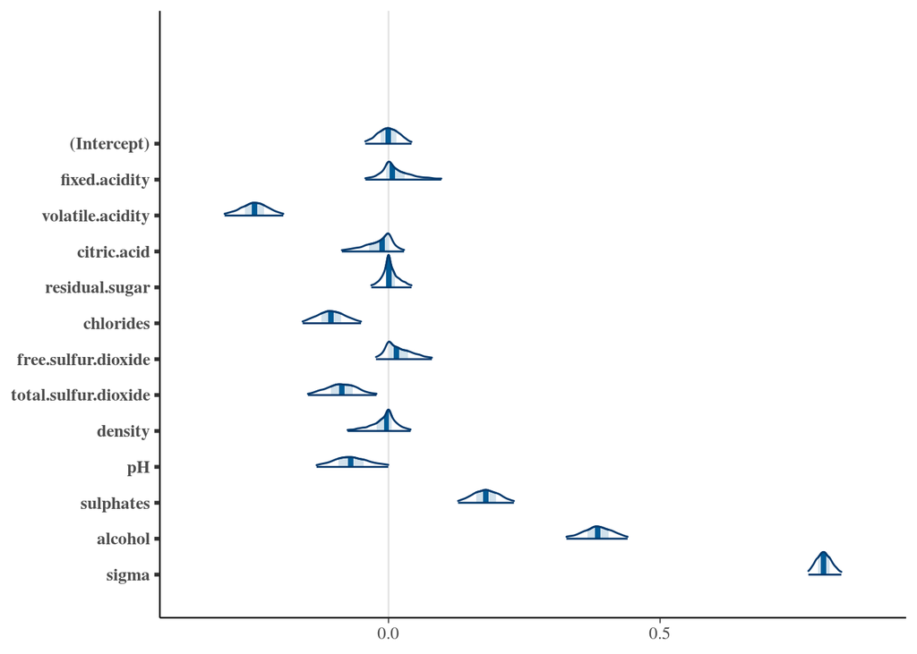

```r
mcmc_areas(as.matrix(fitrhs), prob_outer = .95)
```

Many of the variables are shrunk more towards 0, but still based on these marginals it is not as easy to select the most useful variables as it is with projpred.

The posteriors with normal and regularized horseshoe priors are clearly different, but does this have an effect to the predictions? In case of collinearity prior may have a strong effect on posterior, but a weak effect on posterior predictions. We can use loo to compare

```r
(loorhs <- loo(fitrhs))
```

```
Computed from 4000 by 1359 log-likelihood matrix

         Estimate   SE
elpd_loo  -1634.2 30.5
p_loo        13.8  1.3
looic      3268.4 61.0
------
Monte Carlo SE of elpd_loo is 0.1.

All Pareto k estimates are good (k < 0.5).
See help('pareto-k-diagnostic') for details.
```

```r
loo_compare(loog, loorhs)
```

```
       elpd_diff se_diff
fitrhs  0.0       0.0
fitg   -1.3       1.4
```

There is no difference in predictive performance and thus we don’t need to repeat the projpred variable selection for the model with regularized horseshoe prior.

# References

Piironen, J., Paasiniemi, M. and Vehtari, A. (2018) ‘Projective inference in high-dimensional problems: Prediction and feature selection’, *arXiv preprint arXiv:1810.02406*. Available at: https://arxiv.org/abs/1810.02406.

Piironen, J. and Vehtari, A. (2017a) ‘Comparison of Bayesian predictive methods for model selection’, *Statistics and Computing*, 27(3), pp. 711–735. doi: 10.1007/s11222-016-9649-y.

Piironen, J. and Vehtari, A. (2017b) ‘Sparsity information and regularization in the horseshoe and other shrinkage priors’, *Electronic journal of Statistics*, 11(2), pp. 5018–5051. doi: 10.1214/17-EJS1337SI.

Vehtari, A., Gelman, A. and Gabry, J. (2017) ‘Practical Bayesian model evaluation using leave-one-out cross-validation and WAIC’, *Statistics and Computing*, 27(5), pp. 1413–1432. doi: 10.1007/s11222-016-9696-4.

# Licenses

- Code © 2017-2018, Aki Vehtari, licensed under BSD-3.
- Text © 2017-2018, Aki Vehtari, licensed under CC-BY-NC 4.0.